# matplotlib.axes.Axes.set_yticklabels

**Axes.set_yticklabels(*labels*, *, *minor=False*, *fontdict=None*, **kwargs)[[source]](https://github.com/matplotlib/matplotlib/blob/v3.7.1/lib/matplotlib/axes/_base.py#L73-L74)**

[*Discouraged*] Set the yaxis' tick labels with list of string labels.

Discouraged

The use of this method is discouraged, because of the dependency on tick positions. In most cases, you'll want to use `Axes.set_[x/y/z]ticks(positions, labels)` or `Axes.set_yticks` instead.

If you are using this method, you should always fix the tick positions before, e.g. by using `Axes.set_yticks` or by explicitly setting a `FixedLocator`. Otherwise, ticks are free to move and the labels may end up in unexpected positions.

**Parameters:**

**labels**sequence of str or of `Text`s**

Texts for labeling each tick location in the sequence set by `Axes.set_yticks`; the number of labels must match the number of locations.

**minor**bool**

If True, set minor ticks instead of major ticks.

**fontdict**dict, optional**

A dictionary controlling the appearance of the ticklabels. The default *fontdict* is:

```
{'fontsize': rcParams['axes.titlesize'],
 'fontweight': rcParams['axes.titleweight'],
 'verticalalignment': 'baseline',
 'horizontalalignment': loc}
```

**kwargs**

Text properties.

**Returns:**

**list of `Text`s**

For each tick, includes `tick.label1` if it is visible, then `tick.label2` if it is visible, in that order.

## Examples using `matplotlib.axes.Axes.set_yticklabels`

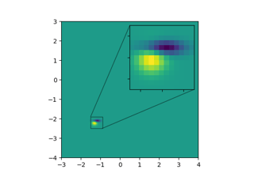

[Zoom region inset axes](https://matplotlib.org/stable/gallery/subplots_axes_and_figures/zoom_inset_axes.html#sphx-glr-gallery-subplots-axes-and-figures-zoom-inset-axes-py)

Zoom region inset axes

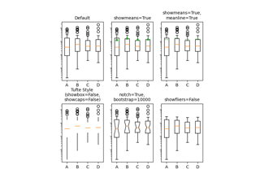

[Artist customization in box plots](https://matplotlib.org/stable/gallery/statistics/boxplot.html#sphx-glr-gallery-statistics-boxplot-py)

Artist customization in box plots

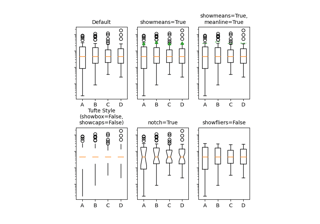

[Boxplot drawer function](https://matplotlib.org/stable/gallery/statistics/bxp.html#sphx-glr-gallery-statistics-bxp-py)

Boxplot drawer function

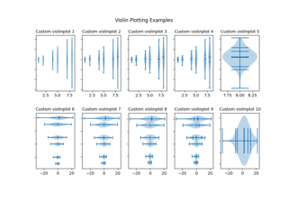

[Violin plot basics](https://matplotlib.org/stable/gallery/statistics/violinplot.html#sphx-glr-gallery-statistics-violinplot-py)

Violin plot basics

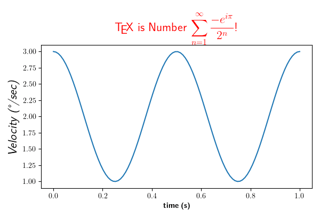

[Rendering math equations using TeX](https://matplotlib.org/stable/gallery/text_labels_and_annotations/tex_demo.html#sphx-glr-gallery-text-labels-and-annotations-tex-demo-py)

Rendering math equations using TeX

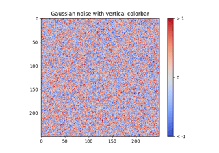

[Colorbar Tick Labelling](https://matplotlib.org/stable/gallery/ticks/colorbar_tick_labelling_demo.html#sphx-glr-gallery-ticks-colorbar-tick-labelling-demo-py)

Colorbar Tick Labelling

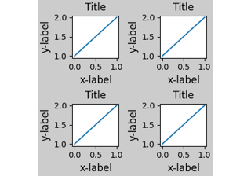

[Constrained Layout Guide](https://matplotlib.org/stable/tutorials/intermediate/constrainedlayout_guide.html#sphx-glr-tutorials-intermediate-constrainedlayout-guide-py)

Constrained Layout Guide

© 2012–2023 Matplotlib Development Team. All rights reserved.  
Licensed under the Matplotlib License Agreement.  
https://matplotlib.org/stable/api/_as_gen/matplotlib.axes.Axes.set_yticklabels.html